# TP4 - Análisis exploratorio de datos

En el siguiente TP vamos a utilizar las herramientas de análisis exploratorio de datos provistas en el curso para analizar un dataset que nunca antes vimos.

## Los datos

Este *dataset* consta de todas las películas originales de **Netflix** estrenadas hasta del 1 de junio de 2021. Además, también incluye todos los documentales y especiales de **Netflix**. Los datos se bajaron de [esta](https://www.kaggle.com/luiscorter/netflix-original-films-imdb-scores) página de **Kaggle**. Los miembros de la comunidad votan las puntuaciones de **IMDB**, y la mayoría de las películas tienen más de 1.000 reseñas.

Las columnas del dataset son:

- Título de la película `Title`
- Género de la película `Genre`
- Fecha original de estreno`Premiere`
- Duración en minutos `Runtime`
- Puntaje en **IMDB** (al 01/06/21) `IMDB Score`
- Idiomas disponibles (al 01/06/21) `Language`

Para más detalles de los datos pueden consultar [acá](https://en.wikipedia.org/wiki/Lists_of_Netflix_original_films).

Los datos están en la carpeta *Practicos/tp4-EDA/data* del repositorio. Los podemos bajar y cargar con `read_csv()` o cargar directo desde la *url*.

```r
library(tidyverse)
library(here)

netflix <- read_csv(here("docs/Practicos/tp4-EDA/data/NetflixOriginals.csv"))
```

## 1 - Mirar los datos

Useamos las funciones `summary()`, `str()` y `glimpse()` para ver qué estructura y qué tipos de variables tiene nuestro dataset

- ¿Tiene valores `NA`?
- ¿Alguna de las variables no es del tipo que corresponde?

  *Ayuda*: Para convertir una fecha de `chr` a `Date` una de las formas más simples es usando el paquete *{lubridate}*. Por ejemplo, la función `mdy("August 5, 2019")` nos da como resutado una fecha `"2019-08-05"`. La ventaja de tener variables `Date` es que nos permite ordenarlas, realizar operaciones con ellas, etc.
- ¿Hay algún valor sospechoso?

Una vez corregidos los probelmas del dataset imprimir un resumen usando la función `skim()` del paquete *{skimr}*.

```r
# Solución
str(netflix)
```

```
#> spec_tbl_df [585 × 6] (S3: spec_tbl_df/tbl_df/tbl/data.frame)
#>  $ Title     : chr [1:585] "Enter the Anime" "Dark Forces" "The App" "The Open House" ...
#>  $ Genre     : chr [1:585] "Documentary" "Thriller" "Science fiction/Drama" "Horror thriller" ...
#>  $ Premiere  : chr [1:585] "August 5, 2019" "August 21, 2020" "December 26, 2019" "January 19, 2018" ...
#>  $ Runtime   : num [1:585] 58 81 79 94 90 147 112 149 73 139 ...
#>  $ IMDB Score: num [1:585] 2.5 2.6 2.6 3.2 3.4 3.5 3.7 3.7 3.9 4.1 ...
#>  $ Language  : chr [1:585] "English/Japanese" "Spanish" "Italian" "English" ...
#>  - attr(*, "spec")=
#>   .. cols(
#>   ..   Title = col_character(),
#>   ..   Genre = col_character(),
#>   ..   Premiere = col_character(),
#>   ..   Runtime = col_double(),
#>   ..   `IMDB Score` = col_double(),
#>   ..   Language = col_character()
#>   .. )
#>  - attr(*, "problems")=<externalptr>
```

```r
summary(netflix)
```

```
#>     Title              Genre             Premiere            Runtime
#>  Length:585         Length:585         Length:585         Min.   :  4.00
#>  Class :character   Class :character   Class :character   1st Qu.: 86.00
#>  Mode  :character   Mode  :character   Mode  :character   Median : 97.00
#>                                                           Mean   : 93.57
#>                                                           3rd Qu.:108.00
#>                                                           Max.   :209.00
#>
#>    IMDB Score      Language
#>  Min.   :2.500   Length:585
#>  1st Qu.:5.700   Class :character
#>  Median :6.350   Mode  :character
#>  Mean   :6.272
#>  3rd Qu.:7.000
#>  Max.   :9.000
#>  NA's   :1
```

```r
# Hay un NA
# El mínimo de duración es raro (4 minutos)
# Los ratings están bien
glimpse(netflix)
```

```
#> Rows: 585
#> Columns: 6
#> $ Title        <chr> "Enter the Anime", "Dark Forces", "The App", "The Open Ho…
#> $ Genre        <chr> "Documentary", "Thriller", "Science fiction/Drama", "Horr…
#> $ Premiere     <chr> "August 5, 2019", "August 21, 2020", "December 26, 2019",…
#> $ Runtime      <dbl> 58, 81, 79, 94, 90, 147, 112, 149, 73, 139, 58, 112, 97, …
#> $ `IMDB Score` <dbl> 2.5, 2.6, 2.6, 3.2, 3.4, 3.5, 3.7, 3.7, 3.9, 4.1, 4.1, 4.…
#> $ Language     <chr> "English/Japanese", "Spanish", "Italian", "English", "Hin…
```

```r
# Premiere es un tipo de variable date y aparece como <chr>

# Arreglemos la fecha
library(lubridate)
netflix <- netflix %>%
  mutate(Premiere = mdy(Premiere))

# Tiramos el NA
netflix <- netflix %>% drop_na()

glimpse(netflix) # Ahora sí
```

```
#> Rows: 584
#> Columns: 6
#> $ Title        <chr> "Enter the Anime", "Dark Forces", "The App", "The Open Ho…
#> $ Genre        <chr> "Documentary", "Thriller", "Science fiction/Drama", "Horr…
#> $ Premiere     <date> 2019-08-05, 2020-08-21, 2019-12-26, 2018-01-19, 2020-10-…
#> $ Runtime      <dbl> 58, 81, 79, 94, 90, 147, 112, 149, 73, 139, 58, 112, 97, …
#> $ `IMDB Score` <dbl> 2.5, 2.6, 2.6, 3.2, 3.4, 3.5, 3.7, 3.7, 3.9, 4.1, 4.1, 4.…
#> $ Language     <chr> "English/Japanese", "Spanish", "Italian", "English", "Hin…
```

```r
library(skimr)
skim(netflix)
```

Data summary

| Name | netflix |
| --- | --- |
| Number of rows | 584 |
| Number of columns | 6 |
| _______________________ |  |
| Column type frequency: |  |
| character | 3 |
| Date | 1 |
| numeric | 2 |
| ________________________ |  |
| Group variables | None |

**Variable type: character**

| skim_variable | n_missing | complete_rate | min | max | empty | n_unique | whitespace |
| --- | --- | --- | --- | --- | --- | --- | --- |
| Title | 0 | 1 | 2 | 105 | 0 | 584 | 0 |
| Genre | 0 | 1 | 3 | 36 | 0 | 115 | 0 |
| Language | 0 | 1 | 4 | 26 | 0 | 38 | 0 |

**Variable type: Date**

| skim_variable | n_missing | complete_rate | min | max | median | n_unique |
| --- | --- | --- | --- | --- | --- | --- |
| Premiere | 0 | 1 | 2014-12-13 | 2021-05-27 | 2019-10-17 | 387 |

**Variable type: numeric**

| skim_variable | n_missing | complete_rate | mean | sd | p0 | p25 | p50 | p75 | p100 | hist |
| --- | --- | --- | --- | --- | --- | --- | --- | --- | --- | --- |
| Runtime | 0 | 1 | 93.58 | 27.76 | 4.0 | 86.0 | 97.00 | 108 | 209 | ▁▂▇▁▁ |
| IMDB Score | 0 | 1 | 6.27 | 0.98 | 2.5 | 5.7 | 6.35 | 7 | 9 | ▁▂▇▇▁ |

```r
# Podemos ver que el valor de duración que parecía raro tal vez no lo sea
```

¿Cuáles son los tres géneros con más estrenos?

```r
netflix %>%
    count(Genre) %>%
    arrange(desc(n)) %>%
    slice_head(n = 3)
```

```
#> # A tibble: 3 × 2
#>   Genre           n
#>   <chr>       <int>
#> 1 Documentary   159
#> 2 Drama          77
#> 3 Comedy         49
```

¿Y los tres idiomas con más estrenos?

```r
netflix %>%
    count(Language) %>%
    arrange(desc(n)) %>%
    slice_head(n = 3)
```

```
#> # A tibble: 3 × 2
#>   Language     n
#>   <chr>    <int>
#> 1 English    401
#> 2 Hindi       33
#> 3 Spanish     31
```

## 2 - Variación

Exploremos con un simple gráfico de barras la cantidad de películas de cada género.

- ¿Cuántos géneros hay?
- ¿Cómo es la distribución por género?

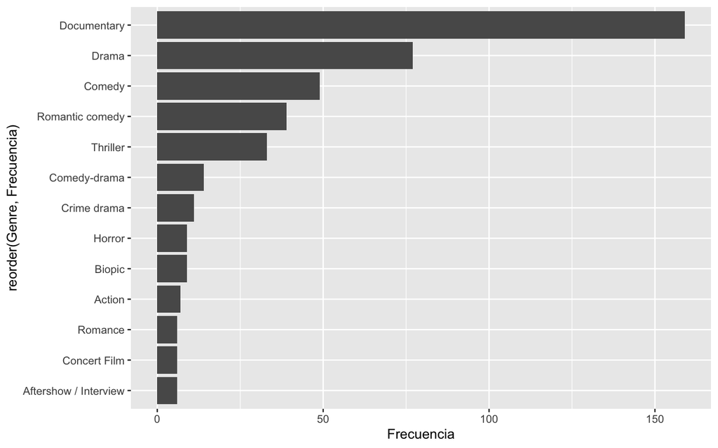

```r
# Solución
netflix %>%
  count(Genre, name = "Frecuencia") %>%
  filter(Frecuencia > 5) %>%
  ggplot(aes(x = reorder(Genre, Frecuencia), y = Frecuencia)) +
  geom_col() +
  coord_flip()
```

Ahora miremos la distribución de duraciones y de rating de **IMDB** ¿Qué podemos decir al respecto?

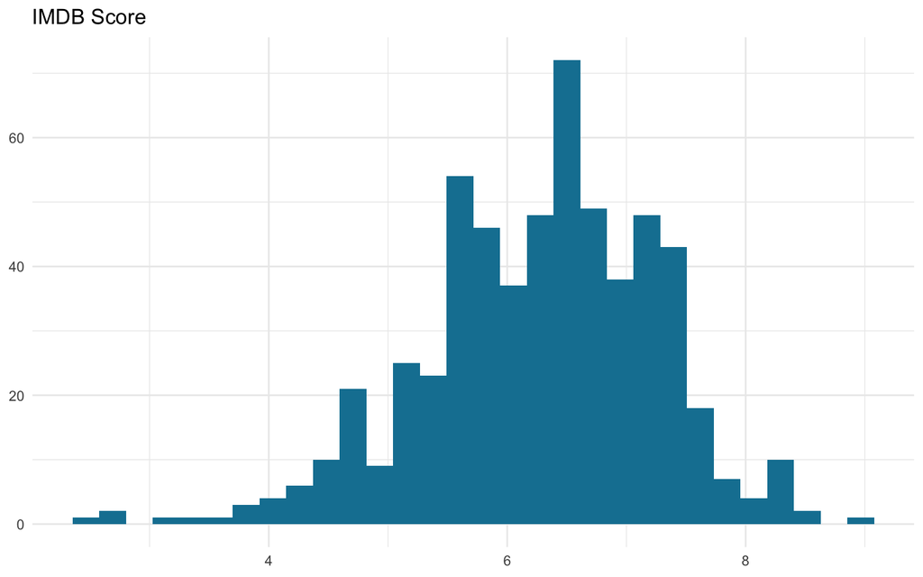

```r
# Solución
netflix %>%
  ggplot(aes(x = `IMDB Score`)) +
  geom_histogram(fill = "#1380A1") +
  labs(x = NULL,
       y = NULL) +
  labs(title = "IMDB Score") +
  theme_minimal()
```

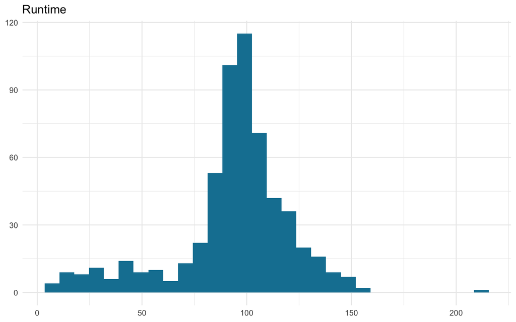

```r
# La distribución es bastante normal pero con cola para abajo

netflix %>%
  ggplot(aes(x = Runtime)) +
  geom_histogram(fill = "#1380A1") +
  labs(x = NULL,
       y = NULL) +
  labs(title = "Runtime") +
  theme_minimal()
```

```r
# pareciera haber un outlier de duración
```

Veamos cómo se distribuyen los ratings de **IMDB** para los géneros *Drama* y *Comedy*.

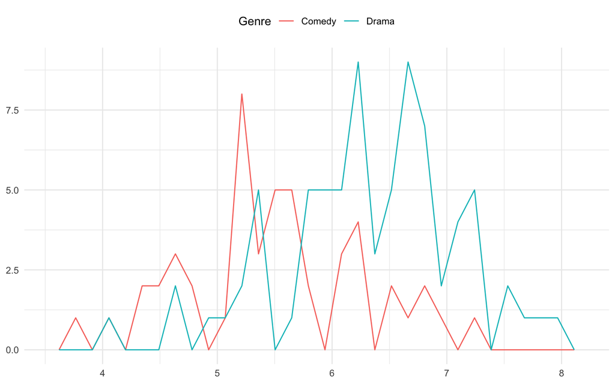

```r
# Solución
generos <-  c("Comedy", "Drama")

netflix %>%
  filter(Genre %in% generos) %>%
  ggplot(aes(x = `IMDB Score`,
             color = Genre)) +
  geom_freqpoly() +
  labs(x = NULL,
       y = NULL) +
  theme_minimal() +
  theme(legend.position = "top")
```

Por último: ¿Qué pasa con las distribuciones de duraciones para *Comedy* y *Documentary*?

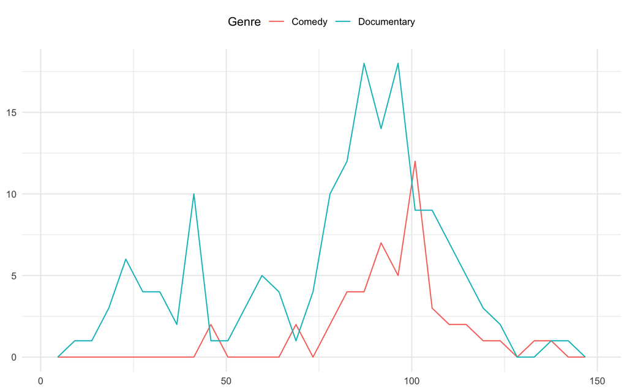

```r
# Solución
generos <-  c("Comedy", "Documentary")

netflix %>%
  filter(Genre %in% generos) %>%
  ggplot(aes(x = Runtime,
             color = Genre)) +
  geom_freqpoly() +
  labs(x = NULL,
       y = NULL) +
  theme_minimal() +
  theme(legend.position = "top")
```

```r
# Hay un montón de documentales cortos
```

## 3 - Covariación

Utilizando un boxplot veamos si hay alguna relación entre las películas de los géneros *Comedy*, *Drama* y *Documentary* y su rating de **IMDB**.

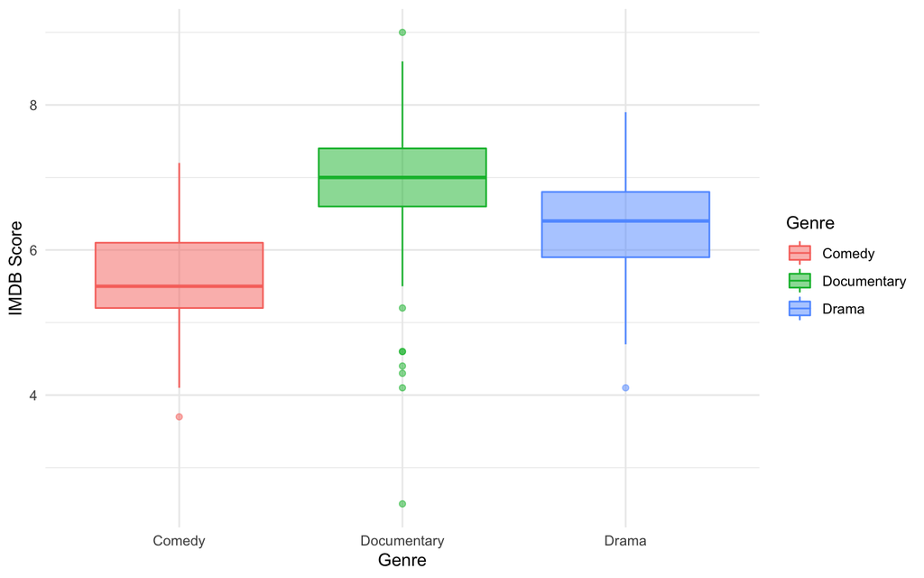

```r
# Solución
generos <- c("Comedy", "Drama", "Documentary")

netflix %>%
  filter(Genre %in% generos) %>%
  ggplot(aes(x = Genre,
             y = `IMDB Score`,
             color = Genre,
             fill = Genre)) +
  geom_boxplot(alpha = .5) +
  theme_minimal()
```

Luego, usando la función `geom_tile()` miremos la cantidad de muestras para las combinaciones de los tres géneros y los tres idiomas con más estrenos.

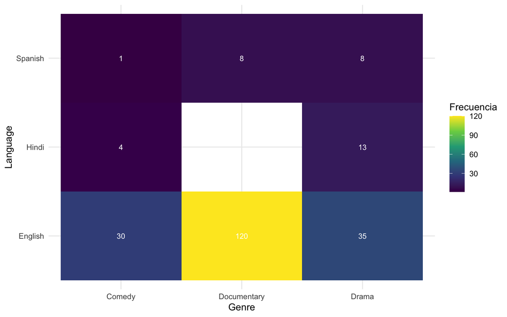

```r
# Solución
generos <- c("Comedy", "Drama", "Documentary")
idiomas <- c("English", "Hindi", "Spanish")

netflix %>%
  filter(Genre %in% generos) %>%
  filter(Language %in% idiomas) %>%
  count(Genre, Language, name = "Frecuencia") %>%
  ggplot(aes(x = Genre, y = Language, fill = Frecuencia)) +
  geom_tile() +
  geom_text(aes(label = Frecuencia), size = 3, color = "white") +
  scale_fill_viridis_c() +
  theme_minimal()
```

Ahora vamos a ver la covariación entre dos variables continuas. Vemos si existe alguna relación entre la fecha de estreno y el rating de **IMDB**.

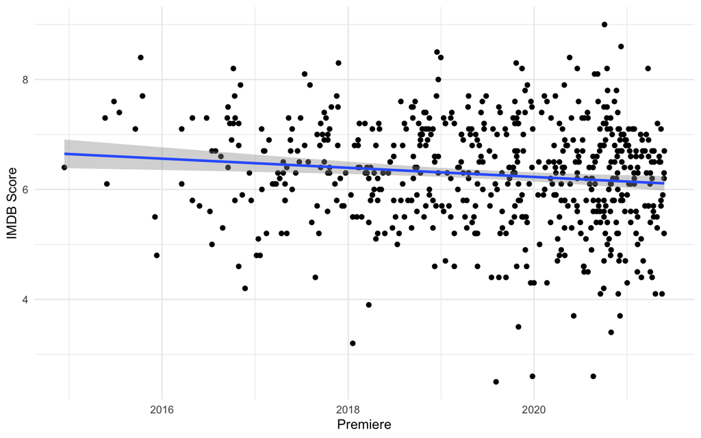

```r
# Solución
netflix %>%
  ggplot(aes(x = Premiere,
             y = `IMDB Score`)) +
  geom_point() +
   geom_smooth(method = lm) +
  theme_minimal()
```

¿Y si nos quedamos con los tres géneros más populares y lo vemos por género?

[figure not shown]

```r
# Solución
netflix %>%
  filter(Genre %in% c("Comedy", "Drama", "Documentary")) %>%
  ggplot(aes(x = Premiere,
             y = `IMDB Score`,
             color = Genre)) +
  geom_point() +
  geom_smooth(method = lm,
              se = FALSE) +
  theme_minimal() +
  theme(legend.position = "top")
```

Por último, utilicemos la función `ggpairs()` de *{GGally}* para ver las distribuciones y correlaciones de todas las variables numéricas de `netflix`.

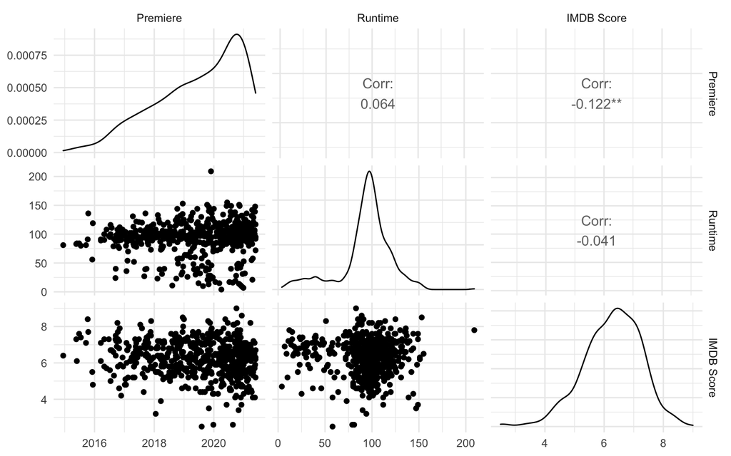

```r
# Solución
library(GGally)

netflix %>%
  select(all_of(c("Premiere", "Runtime", "IMDB Score"))) %>%
  ggpairs() +
  theme_minimal()
```

## 4 - *Outliers*

Usemos la librería *{Routliers}* para ver si tenemos *outliers* univariados en las variables `Runtime` (duración) y `IMDB Score` (rating de IMDB)

```r
# Solución
library(Routliers)

outliers_runtime <- outliers_mad(x = netflix$Runtime)
outliers_runtime
```

```
#> Call:
#> outliers_mad.default(x = netflix$Runtime)
#>
#> Median:
#> [1] 97
#>
#> MAD:
#> [1] 16.3086
#>
#> Limits of acceptable range of values:
#> [1]  48.0742 145.9258
#>
#> Number of detected outliers
#>  extremely low extremely high          total
#>             56             10             66
```

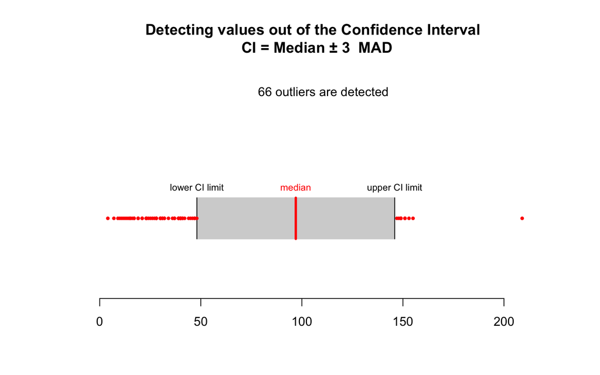

```r
plot_outliers_mad(outliers_runtime,
                  x = netflix$Runtime)
```

```r
netflix %>%
  filter(Runtime < outliers_runtime$limits[1]) %>%
  count(Genre) %>%
  arrange(desc(n))
```

```
#> # A tibble: 14 × 2
#>    Genre                     n
#>    <chr>                 <int>
#>  1 Documentary              32
#>  2 Aftershow / Interview     6
#>  3 Animation / Short         4
#>  4 Animation                 3
#>  5 Comedy                    2
#>  6 Animation / Comedy        1
#>  7 Animation / Musicial      1
#>  8 Anime / Short             1
#>  9 Comedy / Musical          1
#> 10 Drama / Short             1
#> 11 Making-of                 1
#> 12 Mockumentary              1
#> 13 Musical / Short           1
#> 14 Stop Motion               1
```

```r
netflix %>%
  filter(Runtime > outliers_runtime$limits[2])
```

```
#> # A tibble: 10 × 6
#>    Title                          Genre Premiere   Runtime `IMDB Score` Language
#>    <chr>                          <chr> <date>       <dbl>        <dbl> <chr>
#>  1 Drive                          Acti… 2019-11-01     147          3.5 Hindi
#>  2 The Last Days of American Cri… Heis… 2020-06-05     149          3.7 English
#>  3 Army of the Dead               Zomb… 2021-05-21     148          5.9 English
#>  4 Citation                       Drama 2020-11-06     151          6.2 English
#>  5 The Forest of Love             Drama 2019-10-11     151          6.3 Japanese
#>  6 Da 5 Bloods                    War … 2020-06-12     155          6.5 English
#>  7 Raat Akeli Hai                 Thri… 2020-07-31     149          7.3 Hindi
#>  8 Ludo                           Anth… 2020-11-12     149          7.6 Hindi
#>  9 The Irishman                   Crim… 2019-11-27     209          7.8 English
#> 10 Springsteen on Broadway        One-… 2018-12-16     153          8.5 English
```

```r
# Solución
outliers_IMDB <- outliers_mad(x = netflix$`IMDB Score`)
outliers_IMDB
```

```
#> Call:
#> outliers_mad.default(x = netflix$`IMDB Score`)
#>
#> Median:
#> [1] 6.35
#>
#> MAD:
#> [1] 0.96369
#>
#> Limits of acceptable range of values:
#> [1] 3.45893 9.24107
#>
#> Number of detected outliers
#>  extremely low extremely high          total
#>              5              0              5
```

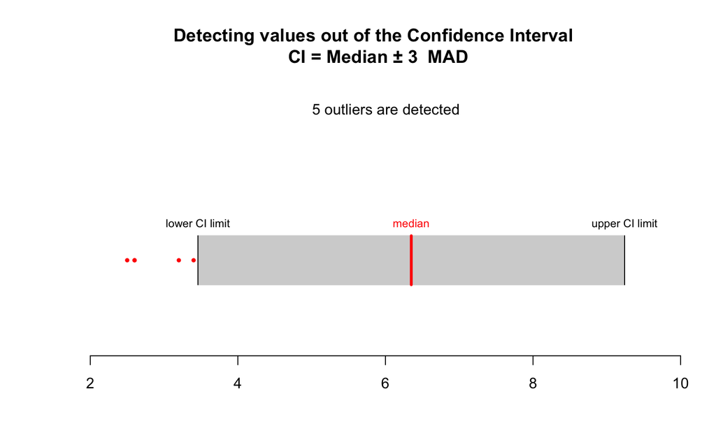

```r
plot_outliers_mad(outliers_IMDB,
                  x = netflix$`IMDB Score`)
```

```r
netflix %>%
  filter(`IMDB Score` < outliers_IMDB$limits[1])
```

```
#> # A tibble: 5 × 6
#>   Title           Genre                 Premiere   Runtime `IMDB Score` Language
#>   <chr>           <chr>                 <date>       <dbl>        <dbl> <chr>
#> 1 Enter the Anime Documentary           2019-08-05      58          2.5 English…
#> 2 Dark Forces     Thriller              2020-08-21      81          2.6 Spanish
#> 3 The App         Science fiction/Drama 2019-12-26      79          2.6 Italian
#> 4 The Open House  Horror thriller       2018-01-19      94          3.2 English
#> 5 Kaali Khuhi     Mystery               2020-10-30      90          3.4 Hindi
```

¿Qué podemos decir de los *outliers* de `Runtime`? ¿Los podemos categorizar de alguna forma? ¿Nos pueden dar alguna información sobre las producciones de **Netflix**?

¿Y sobre los *outliers* de rating de **IMDB**?

Por último, analicemos si hay outliers multivariados en ambas variables.

```r
# Solución
outliers_multi <- outliers_mcd(x = cbind(netflix$Runtime,
                                         netflix$`IMDB Score`))
outliers_multi
```

```
#> Call:
#> outliers_mcd.default(x = cbind(netflix$Runtime, netflix$`IMDB Score`))
#>
#> Limit distance of acceptable values from the centroid :
#> [1] 9.21034
#>
#> Number of detected outliers:
#> total
#>    95
```

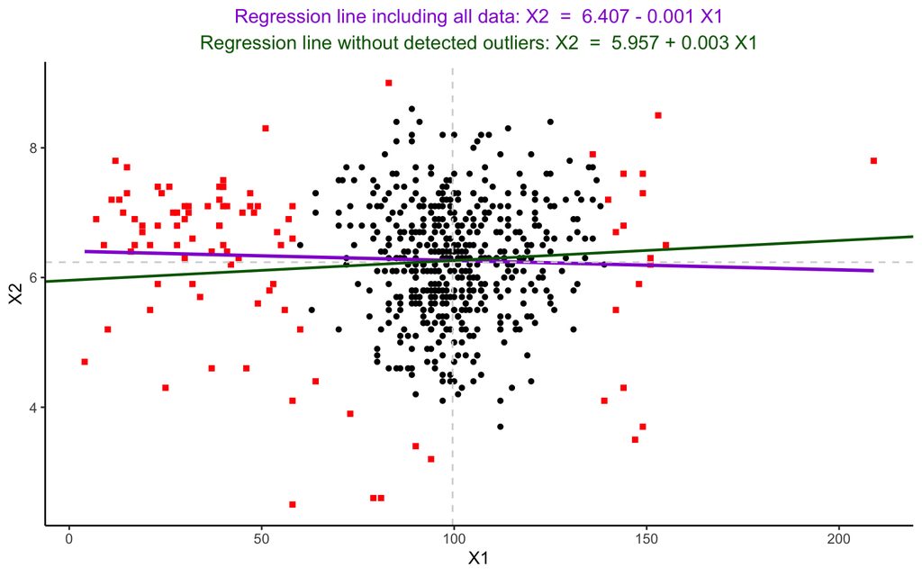

```r
plot_outliers_mcd(outliers_multi,
                  x = cbind(netflix$Runtime,
                            netflix$`IMDB Score`))
```